# Final Project - Report

# INF 385T.9 - Data Wrangling Final Project: Does Positive Pop Music Portend Positive Attitudes?

## Introduction

In this project, we set out to uncover answers to a question that we have pondered for some time: if popular music in any given country is more upbeat, faster tempo, and generally more energetic and danceable, will the people who live be happier? To uncover these answers, we worked with data harvested from Spotify, the World Population Review, and the World Happiness Report to determine whether countries that report higher happiness levels also listen to more upbeat music. By filtering large metadata sets of music to find matches with songs that placed in the top spotify charts for various countries internationally,, we hoped to find trends among popular songs in each nation. By looking at a song’s tempo, danceability, valence, loudness and energy, we were able to match datasets about the top songs in several countries to the World Happiness Report to determine if there is a correlation between the upbeatness of popular music in a given nation and that nation’s happiness.

1. Do happier countries listen to more upbeat, danceable music?
2. If so, will these trends appear regardless of socioeconomic factors like GDP per capita, or will we  
   need to control for wealth and human development?
3. Have these trends changed since 2023, when the analytic data was collected?  
   Or do the happier countries’ trend remain the same?

## Datasets

### Dataset 1: World Happiness Report - 2023

The World Happiness Report, published annually by the University of Oxford’s Wellbeing  
Research Centre in partnership with Gallup, attempts to understand and analyze how people  
experience and process happiness by using a questioning method called Cantril Ladder. The  
participants are asked the following question to rate their “happiness”: “Please imagine a ladder, with steps numbered from 0 at the bottom to 10 at the top. The top of the ladder represents the best possible life for you and the bottom of the ladder represents the worst possible life for you. On which step of the ladder would you say you personally feel you stand at this time?” (Wellbeing Research Centre at the University of Oxford & Gallup, 2025).

This question is carefully worded so that it can be universally translated and understood. On  
average, more than 100,000 people from 140 different countries participate in the survey, and  
data is collected throughout the year to accommodate differences in local factors.  
For this project, the following columns were extracted from the dataset:

- Country name: Official name of the represented country
- Ladder score, which represents the “happiness score” we are mainly interested in.
- The Log GDP per capita measures the average economic well-being per person using a  
  logarithmic scale
- Social support indicated whether participants have someone they can rely on during  
  difficult situations. The answers were logged using a binary system where 0 is no and 1  
  is yes.
- Generosity reflects whether participants have donated any money to charity in the past  
  month. Once again, the answers were logged using a binary system where 0 is no and 1  
  is yes.

To process this data set, we renamed columns for more intuitive understanding, e.g., “Healthy.life.expectancy” became “life_exp.” Moreover, we discarded columns with less relevant or repetitive data, e.g., columns that repeated data in columns like “Social.support” with “Explainedby.Social.Support.”

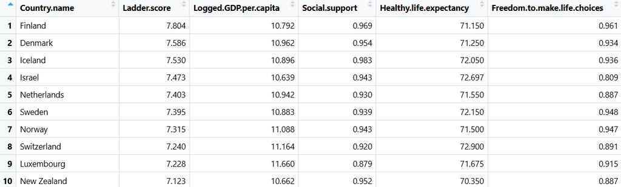

### Dataset 2: Spotify Global Top 50 Song Data (Kaggle)

This dataset, compiled by KEVINAM, was extracted from Spotify’s Top 50 Global Chart  
(10/18/23 to 11/18/23) using the Spotify Web API. This dataset contains not only information  
about top songs in over a hundred nations, but also compiles key music analytics such as danceability, energy, loudness, tempo, and the country where it charted.

- Danceability “describes how suitable a track is for dancing based on a combination of  
  musical elements including tempo, rhythm stability, beat strength, and overall regularity” (Spotify, 2025). Its values range from 0.0 to 1.0, where higher value is considered more ‘danceable.’
- Energy represents the “perceptual measure of intensity” and activity of the song and is  
  also measured from 0 to 1.0 scale (Spotify, 2025).
- The Loudness is the average decibel of the track, typically ranging from -60 dB to 0 dB.
- Valence measures the musical positiveness of a track, with higher scores indicating happier and more cheerful songs, and lower scores suggesting sad, angry, or depressed moods.
- Tempo is the song’s speed represented by beats per minute (BPM).

To process this dataset, we discarded columns feautring metadata that did not describe qualities related to a tracks upbeatness, e.g., “liveness,” which referred to whether a song was recorded live, “key,” which might have some indication of a song’s mood, but which neither of us had the music theory background to interpret accurately at this time, and “vocalness,” which described whether or not a song had vocals, to name three examples.

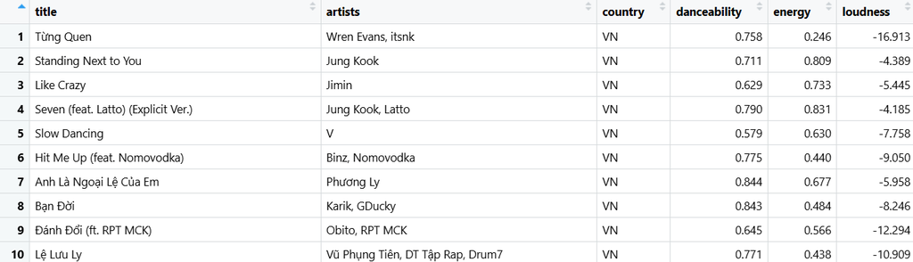

### Dataset 3: World Data 2023 (Kaggle)

This dataset will served as a reference to match the country abbreviations from the Spotify  
dataset to their formal country names. This dataset was the most appropriate mapping source  
since both this and the Spotify datasets were compiled by the same author. From this dataset,  
only the Country and Abbreviation columns were extracted, as this was used to link the Spotify Global charts to the WHR data.

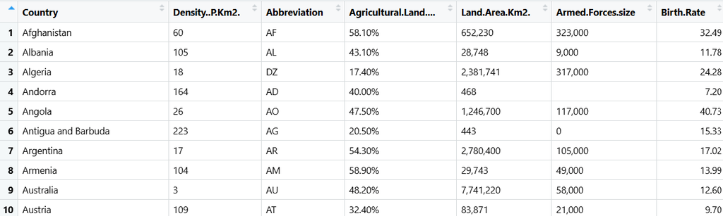

### Dataset 4: Aggregated Weekly Chart (Kworb)

To compare national happiness with current music trends, we used compiled music charts on kworb.net for selected countries. This website updates its chart on a daily and weekly basis; for this project, chart data from 10/16/2025 was used. Only the ‘Artist and Title’ columns was extracted. Artist and title were one column split by the ‘-’ delimiter; this delimiter was also used to indicate whether a track was remastered, e.g., “The Eagles - Hotel California - 2023 Remaster.” Dealing with these delimiters proved to be a challenge, which we will revisit later in our report.

#### New Zealand

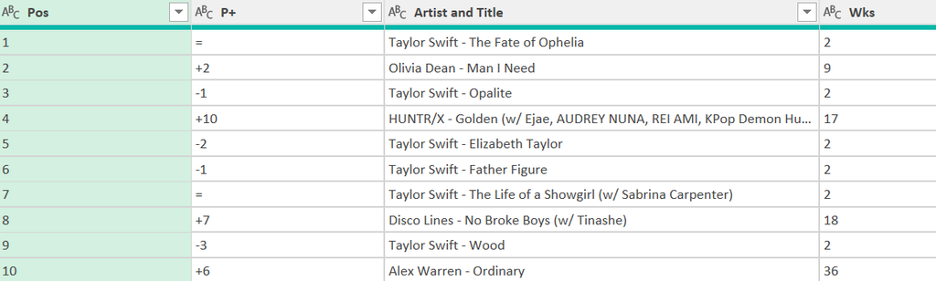

#### South Korea

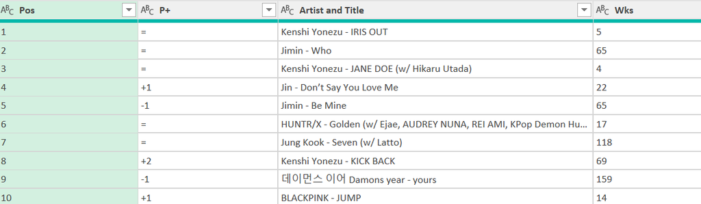

#### USA

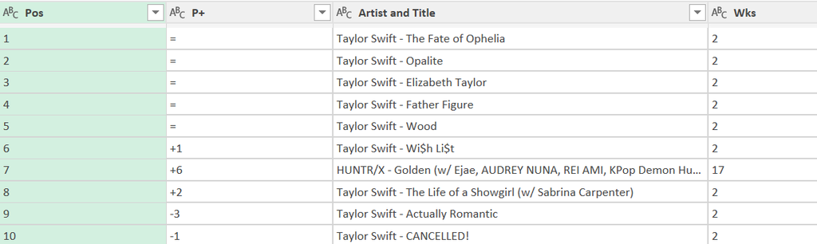

### Dataset 5: Universal Top Spotify Songs (Kaggle)

This dataset compiles top songs that are trending up to June 2025. Though the author of the dataset is different, this dataset has almost identical columns as dataset 2. Thus, the same columns were extracted, and the data was processed similarly:

- Danceability “describes how suitable a track is for dancing based on a combination of  
  musical elements including tempo, rhythm stability, beat strength, and overall regularity” (Spotify, 2025). Its values range from 0.0 to 1.0, where higher value is considered more  
  ‘danceable.’
- Energy represents the “perceptual measure of intensity” and activity of the song and is  
  also measured from 0 to 1.0 scale (Spotify, 2025).
- The Loudness is the average decibel of the track, typically ranging from -60 to 0 dB.
- Valence measures the musical positiveness of a track, with higher scores indicating happier and more cheerful songs, and lower scores suggesting sad, angry, or depressed moods.
- Tempo is the song’s speed represented by beats per minute (BPM).

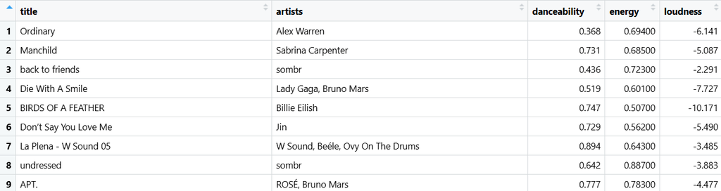

## Conclusion

### Top 10 and Bottom 10 Heat Maps

Top 10 Heat Map

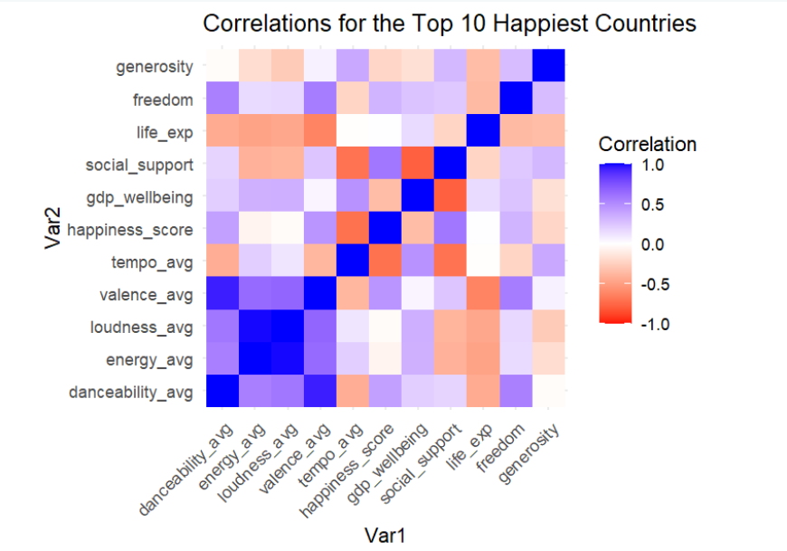

Bottom 10 Heat Map

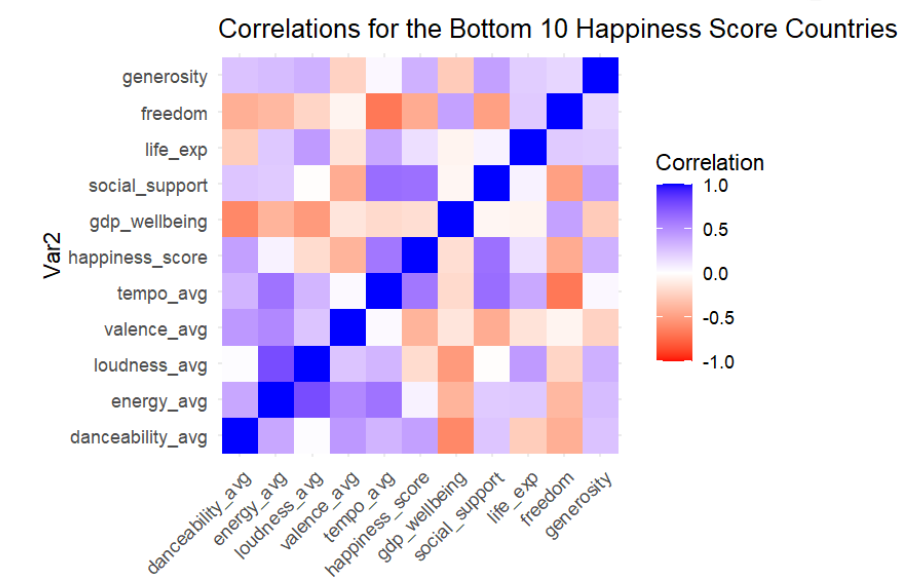

### Challenges

One of the most interesting challenges we faced was ensuring that R Tidyverse, Python Pandas, SQL, and Excel Power Query all produced the exact same results. Since we started working on the R Tidyverse code first, we used those results as our baseline. However, when we tried to replicate the process in Python and SQL, each produced different results and we were stumped as to why the number of rows did not match, despite seemingly using identical datasets and logic.

```sql
#| connection: con

CREATE TABLE new_zealand_25_1 AS
  SELECT TRIM(SUBSTR("Artist and Title", 1, STRPOS("Artist and Title", '-') - 1)) AS artist,
         TRIM(SUBSTR("Artist and Title", STRPOS("Artist and Title", '-') + 1)) AS title
  FROM new_zealand_10_16_25
```

Once those changes were made, we were able to obtain identical rows across all languages and were able to proceed to correlation analysis.

### Tool Learning

To learn the graphing plots, we primarily relied on online sources including Geeks for Geeks and Stack Overflow, as well as looking into R documentation for the Corrplot function in particular. Jennifer introduced Alejandro to Geeks for Geeks. While Alejandro initially attempted to use Gen AI, he found it occasionally erred in describing DuckDB’s capabilities versus other flavors of SQL, and ultimately found that sites like Stack Overflow, the official DuckDB and Pandas documentation, and human-made Power Query how-to sites were more reliable than the occasionally wonky at best and wildly inaccurate at worst ChatGPT. However, ChatGPT did occasionally prove helpful in explaining error codes.

In general, although the R and DuckDB documentation was at times difficult to work through and make sense of, we found that these were generally the best initially resource for learning about new functions and packages, particular those we used to calculate correlations and create visualizations. There was some learning curve in initially figuring out how best to navigate the sites and find the information we were looking for, but these did prove to be the best place to begin. From there, we would search for issues with the particular operations we were using - e.g., “STRING_SPLIT() multiple delimiters” on Stack Overflow.